# Pure Premium Modeling

2026-09-14

Source: https://metricgate.com/blogs/tweedie-glm-insurance-pure-premium/

# Setting Up

```r
# load packages
library(tidyverse)
library(statmod)
library(tweedie)

# load dataset
data <- read_csv("06 - CAS Predictive Modeling Case Competition- Dataset.csv")
head(data)
```

```
## # A tibble: 6 × 15
##   student_id name   class study   gpa greek off_campus distance_to_campus gender
##        <dbl> <chr>  <chr> <chr> <dbl> <chr> <chr>                   <dbl> <chr>
## 1          1 Saiz,… Juni… Huma… 1.20  Non-… On campus                   0 Male
## 2          1 Saiz,… Juni… Huma… 1.20  Non-… On campus                   0 Male
## 3          1 Saiz,… Juni… Huma… 1.20  Non-… On campus                   0 Male
## 4          1 Saiz,… Juni… Huma… 1.20  Non-… On campus                   0 Male
## 5          2 Reddy… Juni… Scie… 0.610 Non-… On campus                   0 Female
## 6          2 Reddy… Juni… Scie… 0.610 Non-… On campus                   0 Female
## # ℹ 6 more variables: sprinklered <lgl>, coverage <chr>, claim_id <dbl>,
## #   amount <dbl>, risk_tier <dbl>, training_holdout <chr>
```

# Data Preprocessing

The given data set has 40,071 rows, but we are told that there are only 10,000 policyholders and 4 different coverage types. Since there’s no duplicated rows, this means there are some policyholders who filed more than one claim. Thus, for policyholders who filed more than one claim per insurance coverage, we need to combine the amount for those claims.

```r
# check if there's any duplicate rows
cat("There are ", sum(duplicated(data)), "duplicated rows.")
```

```
## There are  0 duplicated rows.
```

```r
# converting risk tier into categorical variable
data$risk_tier <- as.character(data$risk_tier)
head(data)
```

```
## # A tibble: 6 × 15
##   student_id name   class study   gpa greek off_campus distance_to_campus gender
##        <dbl> <chr>  <chr> <chr> <dbl> <chr> <chr>                   <dbl> <chr>
## 1          1 Saiz,… Juni… Huma… 1.20  Non-… On campus                   0 Male
## 2          1 Saiz,… Juni… Huma… 1.20  Non-… On campus                   0 Male
## 3          1 Saiz,… Juni… Huma… 1.20  Non-… On campus                   0 Male
## 4          1 Saiz,… Juni… Huma… 1.20  Non-… On campus                   0 Male
## 5          2 Reddy… Juni… Scie… 0.610 Non-… On campus                   0 Female
## 6          2 Reddy… Juni… Scie… 0.610 Non-… On campus                   0 Female
## # ℹ 6 more variables: sprinklered <lgl>, coverage <chr>, claim_id <dbl>,
## #   amount <dbl>, risk_tier <chr>, training_holdout <chr>
```

```r
#Combining Multiple Claims made by the same policyholder and coverage
data <- data |>
  group_by(student_id,coverage) |>
  summarize(
    amount= sum(amount, na.rm = TRUE),
    name= first(name),
    class=first(class),
    study=first(study),
    gpa=first(gpa),
    greek= first(greek),
    off_campus= first(off_campus),
    distance_to_campus = first(distance_to_campus),
    gender= first(gender),
    sprinklered =first(sprinklered),
    risk_tier= first(risk_tier),
    training_holdout= first(training_holdout),
    .groups = "drop"
)

head(data)
```

```
## # A tibble: 6 × 14
##   student_id coverage            amount name  class study   gpa greek off_campus
##        <dbl> <chr>                <dbl> <chr> <chr> <chr> <dbl> <chr> <chr>
## 1          1 Additional Living …      0 Saiz… Juni… Huma… 1.20  Non-… On campus
## 2          1 Guest Medical            0 Saiz… Juni… Huma… 1.20  Non-… On campus
## 3          1 Liability                0 Saiz… Juni… Huma… 1.20  Non-… On campus
## 4          1 Personal Property        0 Saiz… Juni… Huma… 1.20  Non-… On campus
## 5          2 Additional Living …      0 Redd… Juni… Scie… 0.610 Non-… On campus
## 6          2 Guest Medical            0 Redd… Juni… Scie… 0.610 Non-… On campus
## # ℹ 5 more variables: distance_to_campus <dbl>, gender <chr>,
## #   sprinklered <lgl>, risk_tier <chr>, training_holdout <chr>
```

```r
# Grouping the continous variables into 3 bands to make the pricing model easier to rate
data <- data |>
  mutate(
    gpa_interval= case_when(
      gpa<1 ~ "Sub 1.0",
      gpa<3 ~ "1.0 to 2.99",
      gpa>=3 ~"Greater than 3"
    ),

    distance_interval= case_when(
    distance_to_campus==0 ~ "Living On Campus",
    distance_to_campus <=1 ~ "Living 1 mile or less from Campus",
    distance_to_campus > 1 ~ " Living more than 1 mile from Campus"
  )
)
```

# 1. Personal Property

## Full Model

```r
training <- data |> filter(training_holdout == "training",
                           coverage == "Personal Property")
holdout <- data |> filter(training_holdout == "holdout",
                          coverage == "Personal Property")
```

```r
# estimate Tweedie power index p

profile <- tweedie_profile(
  amount ~ risk_tier + study + gpa + greek + off_campus +
    distance_to_campus + gender + sprinklered,
  data = training, p.vec = seq(1.1, 1.6, by = 0.1),
  link.power = 0, do.plot = FALSE
)
p_hat <- profile$p.max
cat("Estimated Tweedie power p:", round(p_hat, 3))
```

```
## Estimated Tweedie power p: 1.324
```

```r
# fits Tweedie GLM w/ log link
personal_prop_full_model <- glm(
  amount ~ risk_tier + study + gpa + greek + off_campus +
    distance_to_campus + gender + sprinklered,
  data = training,
  family = tweedie(var.power = p_hat, link.power = 0),
  control = glm.control(maxit = 15)
)

summary(personal_prop_full_model)
```

```
##
## Call:
## glm(formula = amount ~ risk_tier + study + gpa + greek + off_campus +
##     distance_to_campus + gender + sprinklered, family = tweedie(var.power = p_hat,
##     link.power = 0), data = training, control = glm.control(maxit = 15))
##
## Coefficients:
##                      Estimate Std. Error t value Pr(>|t|)
## (Intercept)          6.574304   0.285527  23.025  < 2e-16 ***
## risk_tier2           0.162276   0.104807   1.548 0.121581
## risk_tier3           0.016198   0.095658   0.169 0.865541
## studyHumanities     -0.310407   0.116906  -2.655 0.007942 **
## studyOther          -0.149843   0.114728  -1.306 0.191567
## studyScience        -0.127951   0.113368  -1.129 0.259088
## gpa                 -0.053366   0.048816  -1.093 0.274337
## greekNon-greek      -1.505003   0.084336 -17.845  < 2e-16 ***
## off_campusOn campus -0.717487   0.104506  -6.866 7.12e-12 ***
## distance_to_campus   0.009136   0.015790   0.579 0.562870
## genderFemale        -0.187703   0.232126  -0.809 0.418756
## genderMale          -0.102724   0.231613  -0.444 0.657405
## genderOther         -0.273196   0.278625  -0.981 0.326861
## sprinkleredTRUE     -0.317679   0.086886  -3.656 0.000258 ***
## ---
## Signif. codes:  0 '***' 0.001 '**' 0.01 '*' 0.05 '.' 0.1 ' ' 1
##
## (Dispersion parameter for Tweedie family taken to be 284.0655)
##
##     Null deviance: 937100  on 7998  degrees of freedom
## Residual deviance: 818397  on 7985  degrees of freedom
## AIC: NA
##
## Number of Fisher Scoring iterations: 8
```

```r
holdout$pred  <- predict(personal_prop_full_model, newdata = holdout, type = "response")

personal_prop_full_avg_amt <- holdout |>
  summarize(observed = mean(amount),
            fitted = mean(pred),
            abs_difference = abs(observed - fitted))
personal_prop_full_avg_amt
```

```
## # A tibble: 1 × 3
##   observed fitted abs_difference
##      <dbl>  <dbl>          <dbl>
## 1     94.1   106.           11.5
```

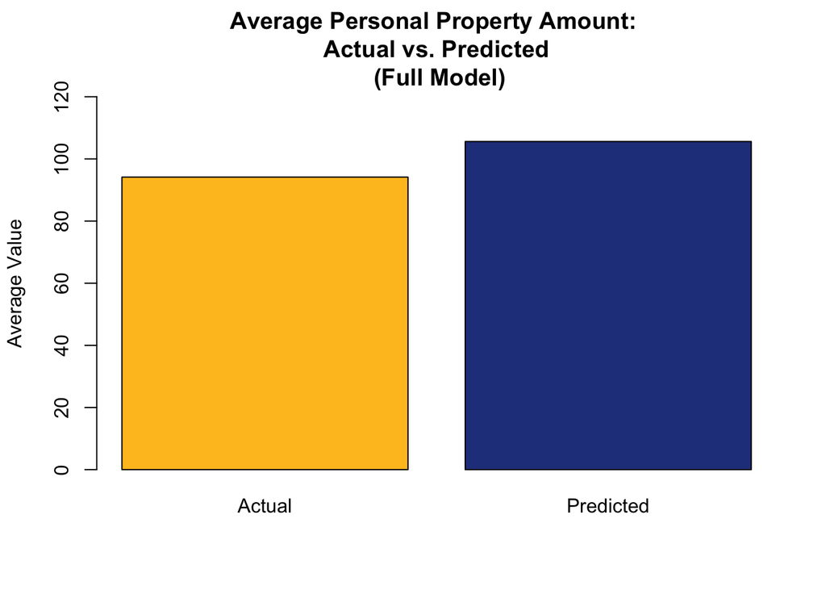

```r
col_means <- colMeans(holdout[c("amount", "pred")])

barplot(col_means,
        col = c("goldenrod1", "royalblue4"),
        main = "Average Personal Property Amount: \n Actual vs. Predicted \n (Full Model)",
        names.arg = c("Actual", "Predicted"),
        ylim = c(0, 120),
        ylab = "Average Value")
```

```r
personal_prop_avg_amt <- holdout |>
  group_by(risk_tier) |>
  summarize(observed = mean(amount),
            fitted = mean(pred),
            abs_difference = abs(observed - fitted))
personal_prop_avg_amt
```

```
## # A tibble: 3 × 4
##   risk_tier observed fitted abs_difference
##   <chr>        <dbl>  <dbl>          <dbl>
## 1 1             77.2  100.0           22.8
## 2 2             97.4  123.            25.8
## 3 3            117.   103.            14.2
```

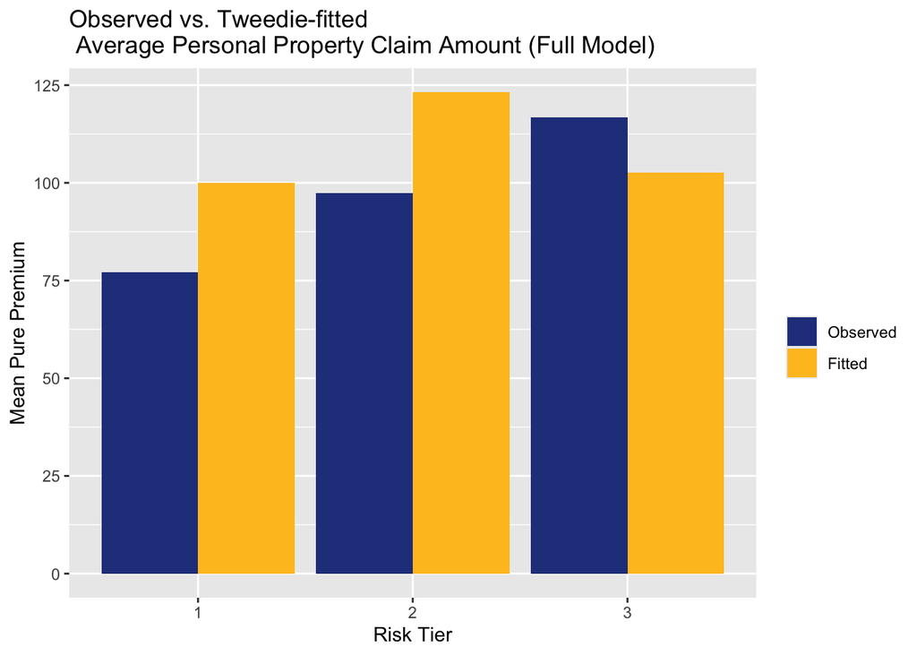

```r
# barplot to compare actual average claim amount vs average predicted claim amount
personal_prop_avg_amt |>
  pivot_longer(cols = c(observed, fitted),
               names_to = "type", values_to = "mean_pp") |>
  mutate(type = factor(type, levels = c("observed", "fitted"),
                       labels = c("Observed", "Fitted"))) |>
  ggplot(aes(x = risk_tier, y = mean_pp, fill = type)) +
  geom_col(position = "dodge") +
  scale_fill_manual(values = c("Observed" = "royalblue4",
                               "Fitted" = "goldenrod1")) +
  labs(title = "Observed vs. Tweedie-fitted \n Average Personal Property Claim Amount (Full Model)",
       x = "Risk Tier", y = "Mean Pure Premium", fill = "")
```

## Variable Selection

Since there are more samples than variables ($n = 40071 > p = 11$), we use Backward Stepwise Selection to perform variable selection. We choose a p-value of 0.05 as our cutoff.

### Iteration 1

Based on the table below, we should drop the variable `distance_to_campus`.

```r
# removing 1 variable
drop1(personal_prop_full_model, test = "F")
```

```
## Single term deletions
##
## Model:
## amount ~ risk_tier + study + gpa + greek + off_campus + distance_to_campus +
##     gender + sprinklered
##                    Df Deviance  F value    Pr(>F)
## <none>                  818397
## risk_tier           2   819128   3.5676 0.0282679 *
## study               3   820414   6.5603 0.0001998 ***
## gpa                 1   818724   3.1943 0.0739325 .
## greek               1   905839 853.1586 < 2.2e-16 ***
## off_campus          1   831726 130.0470 < 2.2e-16 ***
## distance_to_campus  1   818494   0.9468 0.3305734
## gender              3   818958   1.8235 0.1405019
## sprinklered         1   822149  36.6044 1.512e-09 ***
## ---
## Signif. codes:  0 '***' 0.001 '**' 0.01 '*' 0.05 '.' 0.1 ' ' 1
```

```r
personal_prop_model_1 <- update(personal_prop_full_model, . ~ . - distance_to_campus)
summary(personal_prop_model_1)
```

```
##
## Call:
## glm(formula = amount ~ risk_tier + study + gpa + greek + off_campus +
##     gender + sprinklered, family = tweedie(var.power = p_hat,
##     link.power = 0), data = training, control = glm.control(maxit = 15))
##
## Coefficients:
##                     Estimate Std. Error t value Pr(>|t|)
## (Intercept)          6.60948    0.27952  23.646  < 2e-16 ***
## risk_tier2           0.16080    0.10480   1.534 0.124963
## risk_tier3           0.01612    0.09562   0.169 0.866164
## studyHumanities     -0.31145    0.11687  -2.665 0.007714 **
## studyOther          -0.15163    0.11469  -1.322 0.186202
## studyScience        -0.12871    0.11332  -1.136 0.256051
## gpa                 -0.05364    0.04879  -1.099 0.271662
## greekNon-greek      -1.50543    0.08431 -17.855  < 2e-16 ***
## off_campusOn campus -0.75428    0.08265  -9.126  < 2e-16 ***
## genderFemale        -0.18478    0.23199  -0.797 0.425761
## genderMale          -0.10068    0.23148  -0.435 0.663625
## genderOther         -0.26841    0.27841  -0.964 0.335035
## sprinkleredTRUE     -0.31582    0.08686  -3.636 0.000279 ***
## ---
## Signif. codes:  0 '***' 0.001 '**' 0.01 '*' 0.05 '.' 0.1 ' ' 1
##
## (Dispersion parameter for Tweedie family taken to be 283.9421)
##
##     Null deviance: 937100  on 7998  degrees of freedom
## Residual deviance: 818494  on 7986  degrees of freedom
## AIC: NA
##
## Number of Fisher Scoring iterations: 8
```

### Iteration 2

Based on the table below, we should drop the variable `gender` next.

```r
drop1(personal_prop_model_1, test = "F")
```

```
## Single term deletions
##
## Model:
## amount ~ risk_tier + study + gpa + greek + off_campus + gender +
##     sprinklered
##             Df Deviance  F value    Pr(>F)
## <none>           818494
## risk_tier    2   819212   3.5034 0.0301407 *
## study        3   820526   6.6085 0.0001865 ***
## gpa          1   818825   3.2288 0.0723910 .
## greek        1   905998 853.7728 < 2.2e-16 ***
## off_campus   1   842009 229.4331 < 2.2e-16 ***
## gender       3   819040   1.7752 0.1495431
## sprinklered  1   822207  36.2227 1.838e-09 ***
## ---
## Signif. codes:  0 '***' 0.001 '**' 0.01 '*' 0.05 '.' 0.1 ' ' 1
```

```r
personal_prop_model_2 <- update(personal_prop_model_1, . ~ . - gender)
summary(personal_prop_model_2)
```

```
##
## Call:
## glm(formula = amount ~ risk_tier + study + gpa + greek + off_campus +
##     sprinklered, family = tweedie(var.power = p_hat, link.power = 0),
##     data = training, control = glm.control(maxit = 15))
##
## Coefficients:
##                     Estimate Std. Error t value Pr(>|t|)
## (Intercept)          6.46212    0.17019  37.971  < 2e-16 ***
## risk_tier2           0.16179    0.10460   1.547 0.121958
## risk_tier3           0.01695    0.09537   0.178 0.858966
## studyHumanities     -0.30981    0.11654  -2.658 0.007865 **
## studyOther          -0.15289    0.11445  -1.336 0.181643
## studyScience        -0.12705    0.11302  -1.124 0.260995
## gpa                 -0.05223    0.04868  -1.073 0.283307
## greekNon-greek      -1.50632    0.08412 -17.906  < 2e-16 ***
## off_campusOn campus -0.75392    0.08243  -9.146  < 2e-16 ***
## sprinkleredTRUE     -0.31827    0.08664  -3.673 0.000241 ***
## ---
## Signif. codes:  0 '***' 0.001 '**' 0.01 '*' 0.05 '.' 0.1 ' ' 1
##
## (Dispersion parameter for Tweedie family taken to be 282.8237)
##
##     Null deviance: 937100  on 7998  degrees of freedom
## Residual deviance: 819040  on 7989  degrees of freedom
## AIC: NA
##
## Number of Fisher Scoring iterations: 8
```

### Iteration 3

Based on the table below, we should drop the variable `gpa` next.

```r
drop1(personal_prop_model_2, test = "F")
```

```
## Single term deletions
##
## Model:
## amount ~ risk_tier + study + gpa + greek + off_campus + sprinklered
##             Df Deviance  F value    Pr(>F)
## <none>           819040
## risk_tier    2   819766   3.5432 0.0289656 *
## study        3   821058   6.5611 0.0001996 ***
## gpa          1   819354   3.0646 0.0800537 .
## greek        1   906883 856.8275 < 2.2e-16 ***
## off_campus   1   842551 229.3303 < 2.2e-16 ***
## sprinklered  1   822816  36.8311 1.347e-09 ***
## ---
## Signif. codes:  0 '***' 0.001 '**' 0.01 '*' 0.05 '.' 0.1 ' ' 1
```

```r
personal_prop_model_3 <- update(personal_prop_model_2, . ~ . - gpa)
summary(personal_prop_model_3)
```

```
##
## Call:
## glm(formula = amount ~ risk_tier + study + greek + off_campus +
##     sprinklered, family = tweedie(var.power = p_hat, link.power = 0),
##     data = training, control = glm.control(maxit = 15))
##
## Coefficients:
##                     Estimate Std. Error t value Pr(>|t|)
## (Intercept)          6.34093    0.12714  49.873  < 2e-16 ***
## risk_tier2           0.16385    0.10457   1.567 0.117182
## risk_tier3           0.01815    0.09537   0.190 0.849073
## studyHumanities     -0.31433    0.11651  -2.698 0.006994 **
## studyOther          -0.15357    0.11442  -1.342 0.179571
## studyScience        -0.12818    0.11299  -1.134 0.256646
## greekNon-greek      -1.50645    0.08412 -17.909  < 2e-16 ***
## off_campusOn campus -0.75356    0.08242  -9.142  < 2e-16 ***
## sprinkleredTRUE     -0.31716    0.08661  -3.662 0.000252 ***
## ---
## Signif. codes:  0 '***' 0.001 '**' 0.01 '*' 0.05 '.' 0.1 ' ' 1
##
## (Dispersion parameter for Tweedie family taken to be 282.8245)
##
##     Null deviance: 937100  on 7998  degrees of freedom
## Residual deviance: 819354  on 7990  degrees of freedom
## AIC: NA
##
## Number of Fisher Scoring iterations: 8
```

### Iteration 4

Using a p-value cutoff of 0.05, the table below suggests we should stop removing variables. Thus, `personal_prop_model_3` is our final model for predicting the expected claim loss for personal property claims.

```r
drop1(personal_prop_model_3, test = "F")
```

```
## Single term deletions
##
## Model:
## amount ~ risk_tier + study + greek + off_campus + sprinklered
##             Df Deviance  F value    Pr(>F)
## <none>           819354
## risk_tier    2   820097   3.6226   0.02676 *
## study        3   821434   6.7612   0.00015 ***
## greek        1   907223 856.8638 < 2.2e-16 ***
## off_campus   1   842848 229.1000 < 2.2e-16 ***
## sprinklered  1   823106  36.5850 1.527e-09 ***
## ---
## Signif. codes:  0 '***' 0.001 '**' 0.01 '*' 0.05 '.' 0.1 ' ' 1
```

## Final Model

```r
holdout$pred  <- predict(personal_prop_model_3, newdata = holdout, type = "response")

personal_prop_avg_amt <- holdout |>
  summarize(observed = mean(amount),
            fitted = mean(pred),
            abs_difference = abs(observed - fitted))
personal_prop_avg_amt
```

```
## # A tibble: 1 × 3
##   observed fitted abs_difference
##      <dbl>  <dbl>          <dbl>
## 1     94.1   105.           11.2
```

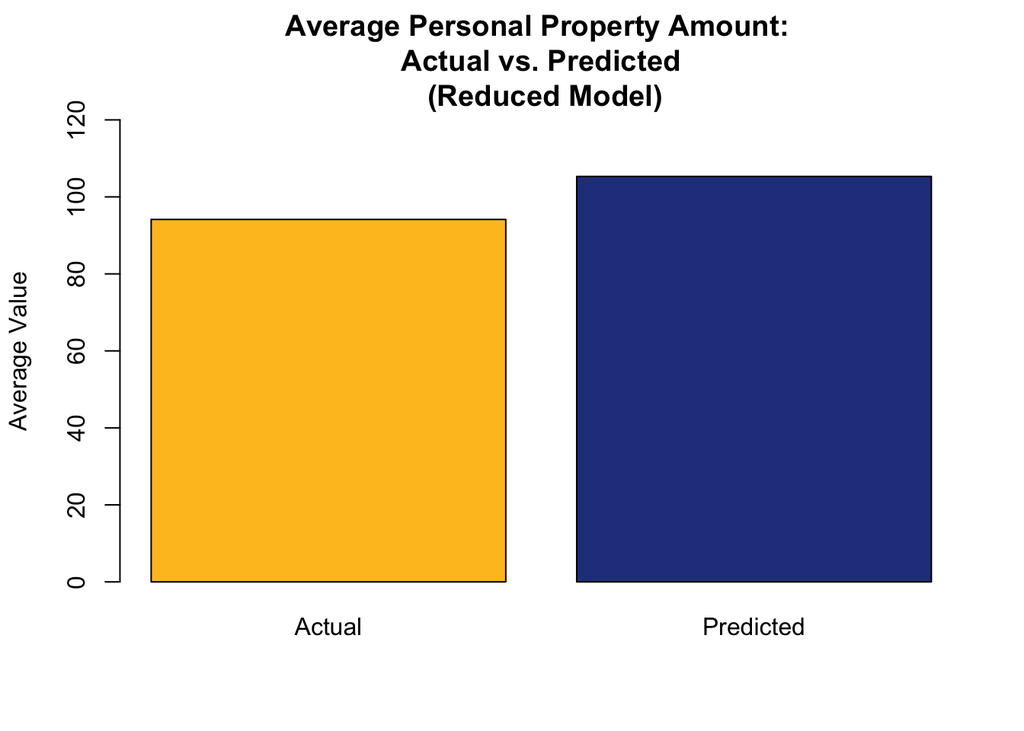

```r
col_means <- colMeans(holdout[c("amount", "pred")])

barplot(col_means,
        col = c("goldenrod1", "royalblue4"),
        main = "Average Personal Property Amount: \n Actual vs. Predicted \n (Reduced Model)",
        names.arg = c("Actual", "Predicted"),
        ylab = "Average Value",
        ylim = c(0, 120))
```

```r
personal_prop_avg_amt <- holdout |>
  group_by(risk_tier) |>
  summarize(observed = mean(amount),
            fitted = mean(pred),
            abs_difference = abs(observed - fitted))
personal_prop_avg_amt
```

```
## # A tibble: 3 × 4
##   risk_tier observed fitted abs_difference
##   <chr>        <dbl>  <dbl>          <dbl>
## 1 1             77.2   99.7           22.6
## 2 2             97.4  123.            25.4
## 3 3            117.   102.            14.5
```

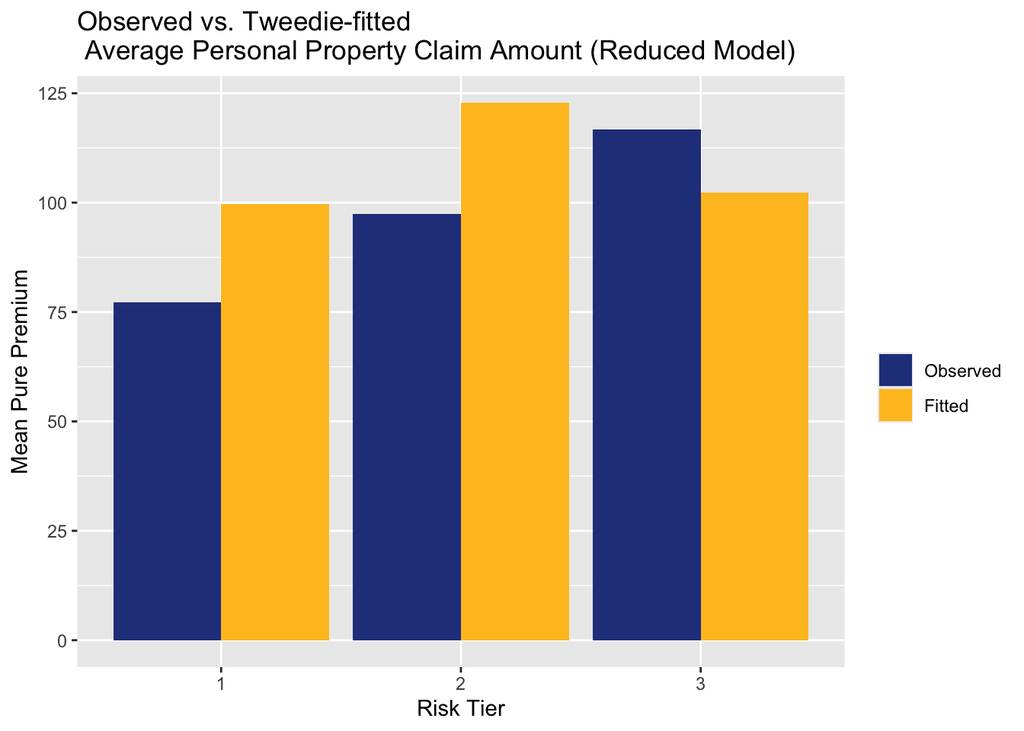

```r
# barplot to compare actual average claim amount vs average predicted claim amount
personal_prop_avg_amt |>
  pivot_longer(cols = c(observed, fitted),
               names_to = "type", values_to = "mean_pp") |>
  mutate(type = factor(type, levels = c("observed", "fitted"),
                       labels = c("Observed", "Fitted"))) |>
  ggplot(aes(x = risk_tier, y = mean_pp, fill = type)) +
  geom_col(position = "dodge") +
  scale_fill_manual(values = c("Observed" = "royalblue4",
                               "Fitted" = "goldenrod1")) +
  labs(title = "Observed vs. Tweedie-fitted \n Average Personal Property Claim Amount (Reduced Model)",
       x = "Risk Tier", y = "Mean Pure Premium", fill = "")
```

# 2. Additional Living Expenses

## Full Model

```r
training <- data |> filter(training_holdout == "training",
                           coverage == "Additional Living Expense")
holdout <- data |> filter(training_holdout == "holdout",
                          coverage == "Additional Living Expense")
```

```r
# estimate Tweedie power index p

profile <- tweedie_profile(
  amount ~ risk_tier + study + gpa + greek + off_campus +
    distance_to_campus + gender + sprinklered,
  data = training, p.vec = seq(1.1, 1.6, by = 0.1),
  link.power = 0, do.plot = FALSE
)
p_hat <- profile$p.max
cat("Estimated Tweedie power p:", round(p_hat, 3))
```

```
## Estimated Tweedie power p: 1.335
```

```r
# fits Tweedie GLM w/ log link
living_exp_full_model <- glm(
  amount ~ risk_tier + study + gpa + greek + off_campus +
    distance_to_campus + sprinklered + risk_tier,
  data = training,
  family = tweedie(var.power = p_hat, link.power = 0),
  control = glm.control(maxit = 15)
)

summary(living_exp_full_model)
```

```
##
## Call:
## glm(formula = amount ~ risk_tier + study + gpa + greek + off_campus +
##     distance_to_campus + sprinklered + risk_tier, family = tweedie(var.power = p_hat,
##     link.power = 0), data = training, control = glm.control(maxit = 15))
##
## Coefficients:
##                      Estimate Std. Error t value Pr(>|t|)
## (Intercept)          7.474547   0.235958  31.677  < 2e-16 ***
## risk_tier2           0.244488   0.138844   1.761  0.07830 .
## risk_tier3           0.336209   0.121313   2.771  0.00559 **
## studyHumanities      0.095027   0.152114   0.625  0.53218
## studyOther           0.145092   0.152507   0.951  0.34144
## studyScience         0.147787   0.151505   0.975  0.32936
## gpa                 -0.109905   0.062552  -1.757  0.07895 .
## greekNon-greek      -1.602768   0.108243 -14.807  < 2e-16 ***
## off_campusOn campus -0.696460   0.135406  -5.143 2.76e-07 ***
## distance_to_campus   0.005511   0.020729   0.266  0.79035
## sprinkleredTRUE     -0.635007   0.109031  -5.824 5.97e-09 ***
## ---
## Signif. codes:  0 '***' 0.001 '**' 0.01 '*' 0.05 '.' 0.1 ' ' 1
##
## (Dispersion parameter for Tweedie family taken to be 896.3089)
##
##     Null deviance: 2053533  on 7998  degrees of freedom
## Residual deviance: 1773283  on 7988  degrees of freedom
## AIC: NA
##
## Number of Fisher Scoring iterations: 9
```

```r
holdout$pred  <- predict(living_exp_full_model, newdata = holdout, type = "response")

living_exp_full_avg_amt <- holdout |>
  summarize(observed = mean(amount),
            fitted = mean(pred),
            abs_difference = abs(observed - fitted))
living_exp_full_avg_amt
```

```
## # A tibble: 1 × 3
##   observed fitted abs_difference
##      <dbl>  <dbl>          <dbl>
## 1     290.   306.           15.9
```

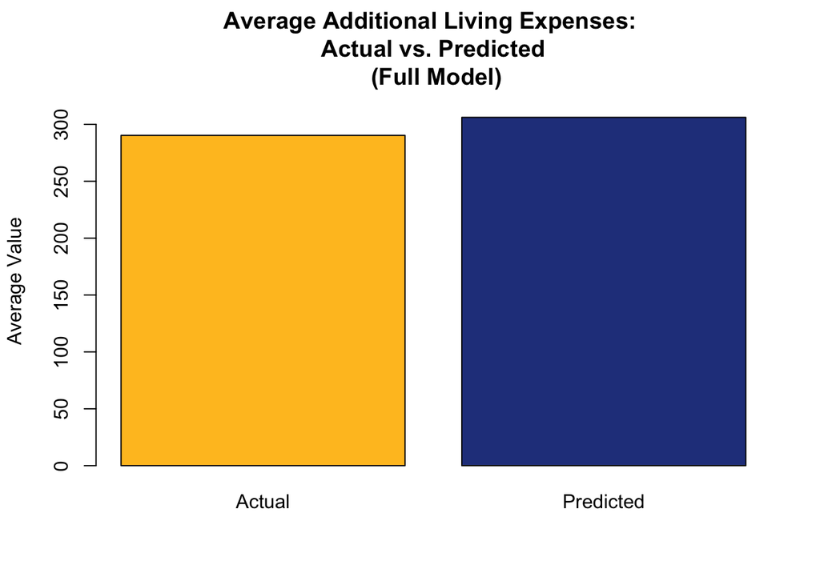

```r
col_means <- colMeans(holdout[c("amount", "pred")])

barplot(col_means,
        col = c("goldenrod1", "royalblue4"),
        main = "Average Additional Living Expenses: \n Actual vs. Predicted \n (Full Model)",
        names.arg = c("Actual", "Predicted"),
        ylim = c(0, 325),
        ylab = "Average Value")
```

```r
living_exp_full_avg_amt <- holdout |>
  group_by(risk_tier) |>
  summarize(observed = mean(amount),
            fitted = mean(pred),
            abs_difference = abs(observed - fitted))
living_exp_full_avg_amt
```

```
## # A tibble: 3 × 4
##   risk_tier observed fitted abs_difference
##   <chr>        <dbl>  <dbl>          <dbl>
## 1 1             315.   255.           59.5
## 2 2             238.   342.          105.
## 3 3             289.   357.           68.9
```

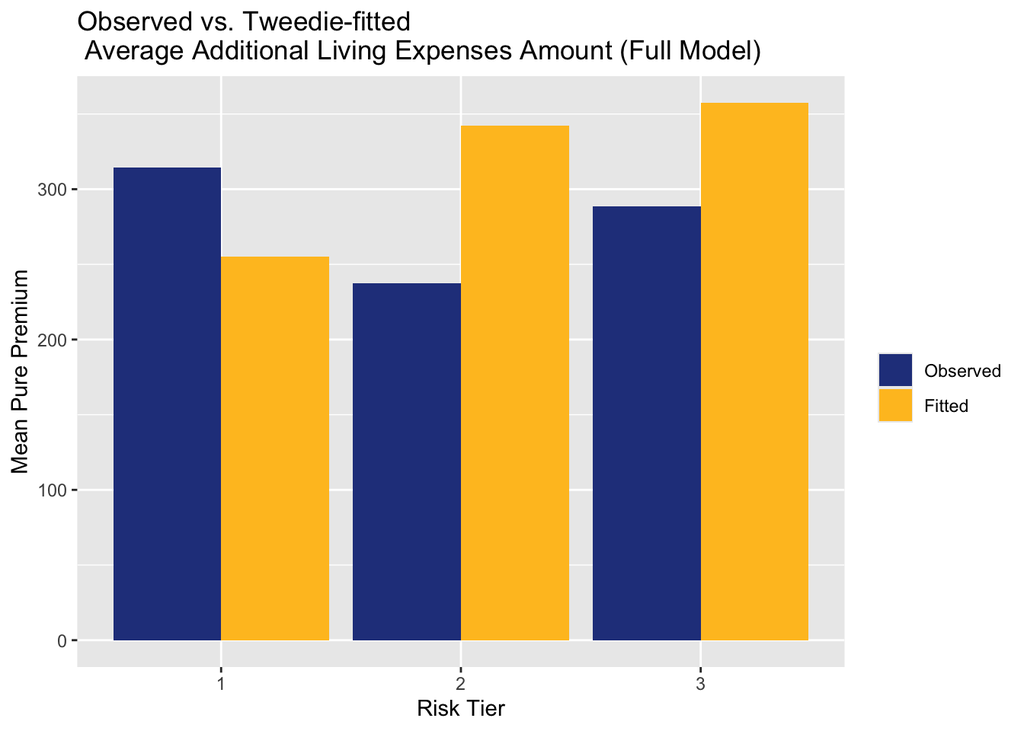

```r
# barplot to compare actual average claim amount vs average predicted claim amount
living_exp_full_avg_amt |>
  pivot_longer(cols = c(observed, fitted),
               names_to = "type", values_to = "mean_pp") |>
  mutate(type = factor(type, levels = c("observed", "fitted"),
                       labels = c("Observed", "Fitted"))) |>
  ggplot(aes(x = risk_tier, y = mean_pp, fill = type)) +
  geom_col(position = "dodge") +
  scale_fill_manual(values = c("Observed" = "royalblue4",
                               "Fitted" = "goldenrod1")) +
  labs(title = "Observed vs. Tweedie-fitted \n Average Additional Living Expenses Amount (Full Model)",
       x = "Risk Tier", y = "Mean Pure Premium", fill = "")
```

## Variable Selection

### Iteration 1

Based on the table below, we should first drop the variable `distance_to_campus`.

```r
drop1(living_exp_full_model, test = "F")
```

```
## Single term deletions
##
## Model:
## amount ~ risk_tier + study + gpa + greek + off_campus + distance_to_campus +
##     sprinklered + risk_tier
##                    Df Deviance  F value    Pr(>F)
## <none>                 1773283
## risk_tier           2  1780603  16.4875  7.15e-08 ***
## study               3  1774380   1.6480 0.1760396
## gpa                 1  1776040  12.4175 0.0004277 ***
## greek               1  1963368 856.2667 < 2.2e-16 ***
## off_campus          1  1796017 102.4103 < 2.2e-16 ***
## distance_to_campus  1  1773341   0.2633 0.6078985
## sprinklered         1  1803252 134.9980 < 2.2e-16 ***
## ---
## Signif. codes:  0 '***' 0.001 '**' 0.01 '*' 0.05 '.' 0.1 ' ' 1
```

```r
living_exp_model1 <- update(living_exp_full_model, ~ . - distance_to_campus)
summary(living_exp_model1)
```

```
##
## Call:
## glm(formula = amount ~ risk_tier + study + gpa + greek + off_campus +
##     sprinklered, family = tweedie(var.power = p_hat, link.power = 0),
##     data = training, control = glm.control(maxit = 15))
##
## Coefficients:
##                     Estimate Std. Error t value Pr(>|t|)
## (Intercept)          7.49533    0.22131  33.869  < 2e-16 ***
## risk_tier2           0.24392    0.13885   1.757  0.07899 .
## risk_tier3           0.33736    0.12127   2.782  0.00542 **
## studyHumanities      0.09541    0.15209   0.627  0.53048
## studyOther           0.14504    0.15249   0.951  0.34157
## studyScience         0.14884    0.15147   0.983  0.32580
## gpa                 -0.10974    0.06253  -1.755  0.07933 .
## greekNon-greek      -1.60261    0.10822 -14.808  < 2e-16 ***
## off_campusOn campus -0.71852    0.10675  -6.731 1.80e-11 ***
## sprinkleredTRUE     -0.63476    0.10899  -5.824 5.96e-09 ***
## ---
## Signif. codes:  0 '***' 0.001 '**' 0.01 '*' 0.05 '.' 0.1 ' ' 1
##
## (Dispersion parameter for Tweedie family taken to be 895.9923)
##
##     Null deviance: 2053533  on 7998  degrees of freedom
## Residual deviance: 1773341  on 7989  degrees of freedom
## AIC: NA
##
## Number of Fisher Scoring iterations: 9
```

### Iteration 2

Based on the table below, we should drop the variable `study` next.

```r
drop1(living_exp_model1, test = "F")
```

```
## Single term deletions
##
## Model:
## amount ~ risk_tier + study + gpa + greek + off_campus + sprinklered
##             Df Deviance  F value    Pr(>F)
## <none>          1773341
## risk_tier    2  1780705  16.5867 6.478e-08 ***
## study        3  1774447   1.6602 0.1733077
## gpa          1  1776090  12.3836 0.0004355 ***
## greek        1  1963395 856.2005 < 2.2e-16 ***
## off_campus   1  1813581 181.2831 < 2.2e-16 ***
## sprinklered  1  1803291 134.9241 < 2.2e-16 ***
## ---
## Signif. codes:  0 '***' 0.001 '**' 0.01 '*' 0.05 '.' 0.1 ' ' 1
```

```r
living_exp_model2 <- update(living_exp_model1, ~ . - study)
summary(living_exp_model2)
```

```
##
## Call:
## glm(formula = amount ~ risk_tier + gpa + greek + off_campus +
##     sprinklered, family = tweedie(var.power = p_hat, link.power = 0),
##     data = training, control = glm.control(maxit = 15))
##
## Coefficients:
##                     Estimate Std. Error t value Pr(>|t|)
## (Intercept)          7.59847    0.19893  38.197  < 2e-16 ***
## risk_tier2           0.23708    0.13895   1.706  0.08800 .
## risk_tier3           0.33566    0.12126   2.768  0.00565 **
## gpa                 -0.10916    0.06256  -1.745  0.08104 .
## greekNon-greek      -1.60754    0.10814 -14.866  < 2e-16 ***
## off_campusOn campus -0.72335    0.10675  -6.776 1.32e-11 ***
## sprinkleredTRUE     -0.63146    0.10894  -5.796 7.03e-09 ***
## ---
## Signif. codes:  0 '***' 0.001 '**' 0.01 '*' 0.05 '.' 0.1 ' ' 1
##
## (Dispersion parameter for Tweedie family taken to be 896.9185)
##
##     Null deviance: 2053533  on 7998  degrees of freedom
## Residual deviance: 1774447  on 7992  degrees of freedom
## AIC: NA
##
## Number of Fisher Scoring iterations: 8
```

### Iteration 3

Using a p-value cutoff of 0.05, the table below suggests we should stop removing variables.

```r
drop1(living_exp_model2, test = "F")
```

```
## Single term deletions
##
## Model:
## amount ~ risk_tier + gpa + greek + off_campus + sprinklered
##             Df Deviance F value    Pr(>F)
## <none>          1774447
## risk_tier    2  1781697  16.327 8.392e-08 ***
## gpa          1  1777169  12.260 0.0004654 ***
## greek        1  1967358 868.858 < 2.2e-16 ***
## off_campus   1  1815354 184.243 < 2.2e-16 ***
## sprinklered  1  1804155 133.802 < 2.2e-16 ***
## ---
## Signif. codes:  0 '***' 0.001 '**' 0.01 '*' 0.05 '.' 0.1 ' ' 1
```

## Final Model

```r
holdout$pred  <- predict(living_exp_model2, newdata = holdout, type = "response")

living_exp_avg_amt <- holdout |>
  summarize(observed = mean(amount),
            fitted = mean(pred),
            abs_difference = abs(observed - fitted))
living_exp_avg_amt
```

```
## # A tibble: 1 × 3
##   observed fitted abs_difference
##      <dbl>  <dbl>          <dbl>
## 1     290.   307.           16.6
```

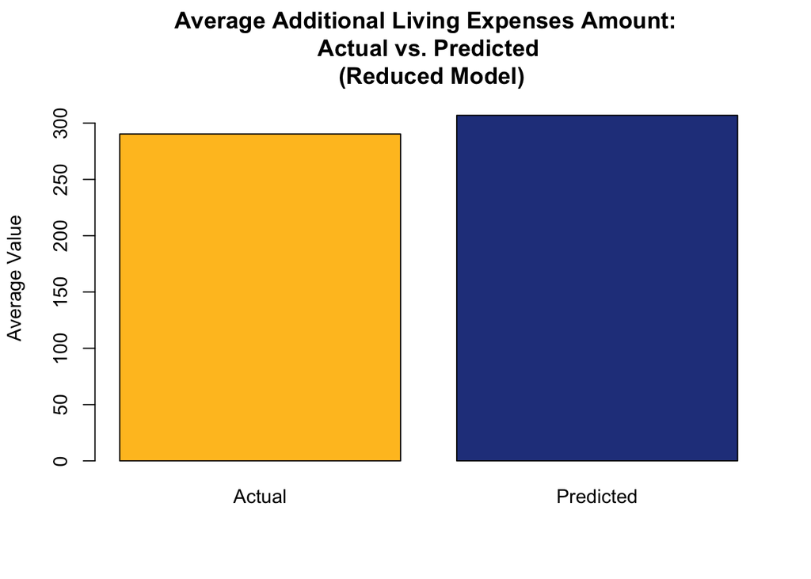

```r
col_means <- colMeans(holdout[c("amount", "pred")])

barplot(col_means,
        col = c("goldenrod1", "royalblue4"),
        main = "Average Additional Living Expenses Amount: \n Actual vs. Predicted \n (Reduced Model)",
        names.arg = c("Actual", "Predicted"),
        ylim = c(0, 325),
        ylab = "Average Value")
```

```r
living_exp_avg_amt <- holdout |>
  group_by(risk_tier) |>
  summarize(observed = mean(amount),
            fitted = mean(pred),
            abs_difference = abs(observed - fitted))
living_exp_avg_amt
```

```
## # A tibble: 3 × 4
##   risk_tier observed fitted abs_difference
##   <chr>        <dbl>  <dbl>          <dbl>
## 1 1             315.   257.           57.9
## 2 2             238.   341.          103.
## 3 3             289.   358.           70.0
```

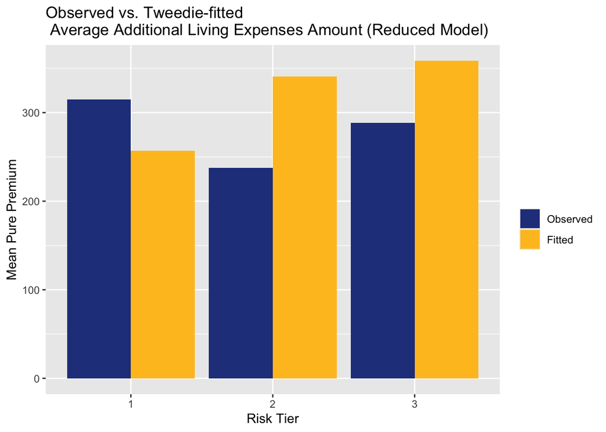

```r
# barplot to compare actual average claim amount vs average predicted claim amount
living_exp_avg_amt |>
  pivot_longer(cols = c(observed, fitted),
               names_to = "type", values_to = "mean_pp") |>
  mutate(type = factor(type, levels = c("observed", "fitted"),
                       labels = c("Observed", "Fitted"))) |>
  ggplot(aes(x = risk_tier, y = mean_pp, fill = type)) +
  geom_col(position = "dodge") +
  scale_fill_manual(values = c("Observed" = "royalblue4",
                               "Fitted" = "goldenrod1")) +
  labs(title = "Observed vs. Tweedie-fitted \n Average Additional Living Expenses Amount (Reduced Model)",
       x = "Risk Tier", y = "Mean Pure Premium", fill = "")
```

# 3. Liability Protection

## Full Model

```r
training <- data |> filter(training_holdout == "training",
                           coverage == "Liability")
holdout <- data |> filter(training_holdout == "holdout",
                          coverage == "Liability")
```

```r
# estimate Tweedie power index p

profile <- tweedie_profile(
  amount ~ risk_tier + study + gpa + greek + off_campus +
    distance_to_campus + gender + sprinklered,
  data = training, p.vec = seq(1.1, 1.6, by = 0.1),
  link.power = 0, do.plot = FALSE
)
p_hat <- profile$p.max
cat("Estimated Tweedie power p:", round(p_hat, 3))
```

```
## Estimated Tweedie power p: 1.447
```

```r
# fits Tweedie GLM w/ log link
liability_full_model <- glm(
  amount ~ risk_tier + study + gpa + greek + off_campus +
    distance_to_campus + gender + sprinklered,
  data = training,
  family = tweedie(var.power = p_hat, link.power = 0),
  control = glm.control(maxit = 15)
)

summary(liability_full_model)
```

```
##
## Call:
## glm(formula = amount ~ risk_tier + study + gpa + greek + off_campus +
##     distance_to_campus + gender + sprinklered, family = tweedie(var.power = p_hat,
##     link.power = 0), data = training, control = glm.control(maxit = 15))
##
## Coefficients:
##                     Estimate Std. Error t value Pr(>|t|)
## (Intercept)          5.59873    1.15414   4.851 1.25e-06 ***
## risk_tier2          -0.03517    0.41729  -0.084   0.9328
## risk_tier3           0.25400    0.35200   0.722   0.4706
## studyHumanities     -0.06879    0.43278  -0.159   0.8737
## studyOther          -0.01015    0.43360  -0.023   0.9813
## studyScience        -0.32439    0.44996  -0.721   0.4710
## gpa                 -0.01532    0.18637  -0.082   0.9345
## greekNon-greek      -1.59923    0.32478  -4.924 8.65e-07 ***
## off_campusOn campus -0.71811    0.39381  -1.824   0.0683 .
## distance_to_campus   0.11317    0.04750   2.382   0.0172 *
## genderFemale         0.27924    0.96252   0.290   0.7717
## genderMale           0.05213    0.96571   0.054   0.9569
## genderOther         -0.37787    1.16033  -0.326   0.7447
## sprinkleredTRUE     -0.47947    0.32723  -1.465   0.1429
## ---
## Signif. codes:  0 '***' 0.001 '**' 0.01 '*' 0.05 '.' 0.1 ' ' 1
##
## (Dispersion parameter for Tweedie family taken to be 1773.922)
##
##     Null deviance: 598260  on 7998  degrees of freedom
## Residual deviance: 519518  on 7985  degrees of freedom
## AIC: NA
##
## Number of Fisher Scoring iterations: 13
```

```r
holdout$pred  <- predict(liability_full_model, newdata = holdout, type = "response")

liability_full_avg_amt <- holdout |>
  summarize(observed = mean(amount),
            fitted = mean(pred),
            abs_difference = abs(observed - fitted))
liability_full_avg_amt
```

```
## # A tibble: 1 × 3
##   observed fitted abs_difference
##      <dbl>  <dbl>          <dbl>
## 1     95.6   76.2           19.4
```

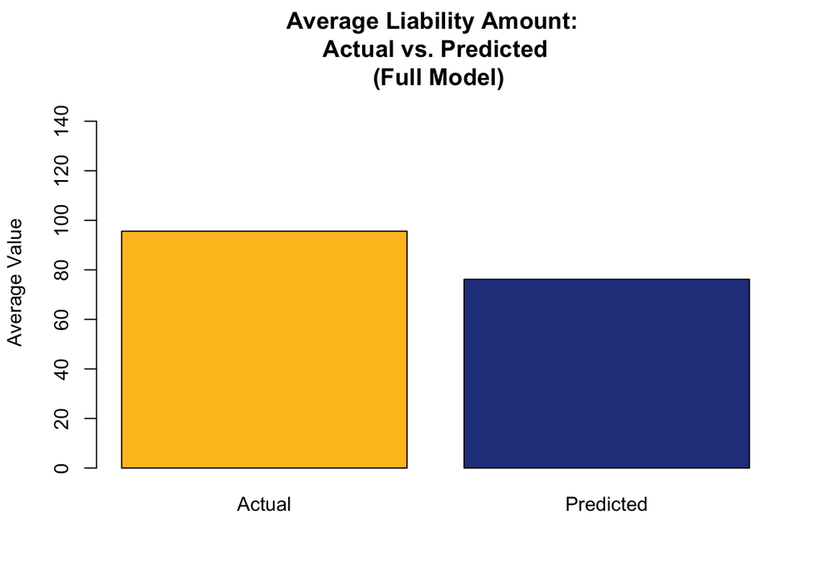

```r
col_means <- colMeans(holdout[c("amount", "pred")])

barplot(col_means,
        col = c("goldenrod1", "royalblue4"),
        main = "Average Liability Amount: \n Actual vs. Predicted \n (Full Model)",
        names.arg = c("Actual", "Predicted"),
        ylim = c(0, 150),
        ylab = "Average Value")
```

```r
liability_full_avg_amt <- holdout |>
  group_by(risk_tier) |>
  summarize(observed = mean(amount),
            fitted = mean(pred),
            abs_difference = abs(observed - fitted))
liability_full_avg_amt
```

```
## # A tibble: 3 × 4
##   risk_tier observed fitted abs_difference
##   <chr>        <dbl>  <dbl>          <dbl>
## 1 1            101.    67.6           33.1
## 2 2            112.    66.7           45.0
## 3 3             78.0   94.8           16.8
```

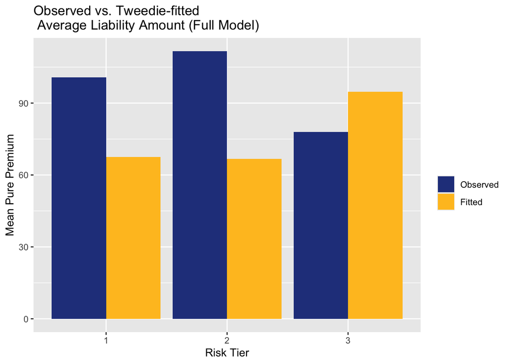

```r
# barplot to compare actual average claim amount vs average predicted claim amount
liability_full_avg_amt |>
  pivot_longer(cols = c(observed, fitted),
               names_to = "type", values_to = "mean_pp") |>
  mutate(type = factor(type, levels = c("observed", "fitted"),
                       labels = c("Observed", "Fitted"))) |>
  ggplot(aes(x = risk_tier, y = mean_pp, fill = type)) +
  geom_col(position = "dodge") +
  scale_fill_manual(values = c("Observed" = "royalblue4",
                               "Fitted" = "goldenrod1")) +
  labs(title = "Observed vs. Tweedie-fitted \n Average Liability Amount (Full Model)",
       x = "Risk Tier", y = "Mean Pure Premium", fill = "")
```

## Variable Selection

### Iteration 1

The table below suggests we drop the variable `gpa`.

```r
drop1(liability_full_model, test = "F")
```

```
## Single term deletions
##
## Model:
## amount ~ risk_tier + study + gpa + greek + off_campus + distance_to_campus +
##     gender + sprinklered
##                    Df Deviance  F value    Pr(>F)
## <none>                  519518
## risk_tier           2   520678   8.9160 0.0001356 ***
## study               3   520645   5.7745 0.0006114 ***
## gpa                 1   519529   0.1670 0.6827910
## greek               1   560083 623.4771 < 2.2e-16 ***
## off_campus          1   525031  84.7340 < 2.2e-16 ***
## distance_to_campus  1   527309 119.7389 < 2.2e-16 ***
## gender              3   521374   9.5078 2.888e-06 ***
## sprinklered         1   523025  53.9013 2.316e-13 ***
## ---
## Signif. codes:  0 '***' 0.001 '**' 0.01 '*' 0.05 '.' 0.1 ' ' 1
```

```r
liability_model1 <- update(liability_full_model, ~ . - gpa)
summary(liability_model1)
```

```
##
## Call:
## glm(formula = amount ~ risk_tier + study + greek + off_campus +
##     distance_to_campus + gender + sprinklered, family = tweedie(var.power = p_hat,
##     link.power = 0), data = training, control = glm.control(maxit = 15))
##
## Coefficients:
##                     Estimate Std. Error t value Pr(>|t|)
## (Intercept)          5.55580    1.06025   5.240 1.65e-07 ***
## risk_tier2          -0.03574    0.41724  -0.086   0.9317
## risk_tier3           0.25407    0.35190   0.722   0.4703
## studyHumanities     -0.07037    0.43252  -0.163   0.8708
## studyOther          -0.01318    0.43359  -0.030   0.9758
## studyScience        -0.32432    0.44973  -0.721   0.4708
## greekNon-greek      -1.59950    0.32470  -4.926 8.56e-07 ***
## off_campusOn campus -0.71473    0.39378  -1.815   0.0696 .
## distance_to_campus   0.11317    0.04751   2.382   0.0172 *
## genderFemale         0.28641    0.96302   0.297   0.7662
## genderMale           0.05663    0.96634   0.059   0.9533
## genderOther         -0.37071    1.16054  -0.319   0.7494
## sprinkleredTRUE     -0.47765    0.32715  -1.460   0.1443
## ---
## Signif. codes:  0 '***' 0.001 '**' 0.01 '*' 0.05 '.' 0.1 ' ' 1
##
## (Dispersion parameter for Tweedie family taken to be 1773.217)
##
##     Null deviance: 598260  on 7998  degrees of freedom
## Residual deviance: 519529  on 7986  degrees of freedom
## AIC: NA
##
## Number of Fisher Scoring iterations: 13
```

### Iteration 2

The table below suggests we stop dropping variables. So `liability_mdoel1` is our final model.

```r
drop1(liability_model1, test = "F")
```

```
## Single term deletions
##
## Model:
## amount ~ risk_tier + study + greek + off_campus + distance_to_campus +
##     gender + sprinklered
##                    Df Deviance  F value    Pr(>F)
## <none>                  519529
## risk_tier           2   520692   8.9400 0.0001324 ***
## study               3   520649   5.7375 0.0006444 ***
## greek               1   560126 624.0374 < 2.2e-16 ***
## off_campus          1   525053  84.9172 < 2.2e-16 ***
## distance_to_campus  1   527319 119.7428 < 2.2e-16 ***
## gender              3   521409   9.6347 2.404e-06 ***
## sprinklered         1   523026  53.7518 2.497e-13 ***
## ---
## Signif. codes:  0 '***' 0.001 '**' 0.01 '*' 0.05 '.' 0.1 ' ' 1
```

## Final Model

```r
holdout$pred  <- predict(liability_model1, newdata = holdout, type = "response")

liability_avg_amt <- holdout |>
  summarize(observed = mean(amount),
            fitted = mean(pred),
            abs_difference = abs(observed - fitted))
liability_avg_amt
```

```
## # A tibble: 1 × 3
##   observed fitted abs_difference
##      <dbl>  <dbl>          <dbl>
## 1     95.6   76.0           19.6
```

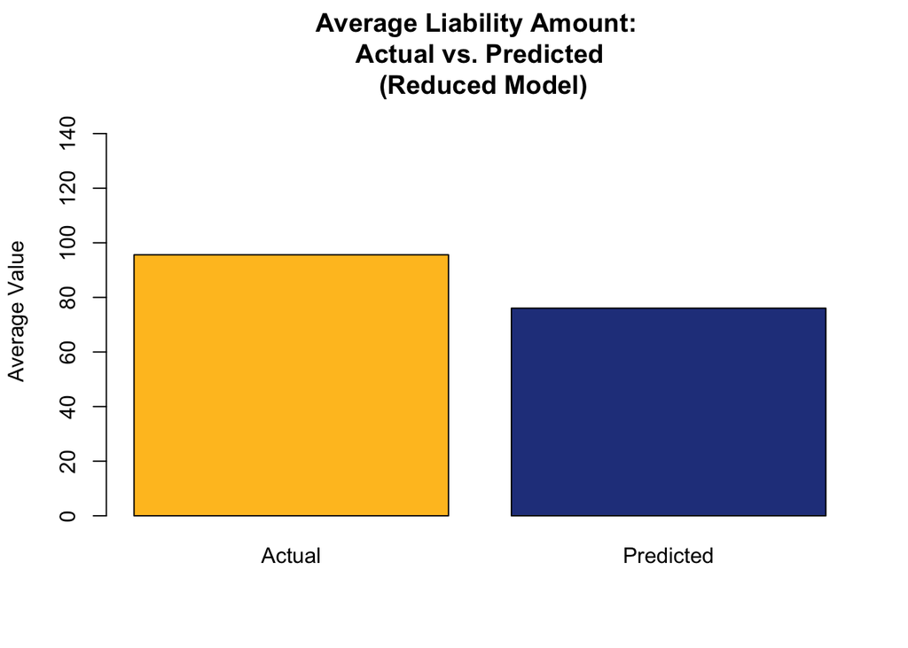

```r
col_means <- colMeans(holdout[c("amount", "pred")])

barplot(col_means,
        col = c("goldenrod1", "royalblue4"),
        main = "Average Liability Amount: \n Actual vs. Predicted \n (Reduced Model)",
        names.arg = c("Actual", "Predicted"),
        ylim = c(0, 150),
        ylab = "Average Value")
```

```r
liability_avg_amt <- holdout |>
  group_by(risk_tier) |>
  summarize(observed = mean(amount),
            fitted = mean(pred),
            abs_difference = abs(observed - fitted))
liability_avg_amt
```

```
## # A tibble: 3 × 4
##   risk_tier observed fitted abs_difference
##   <chr>        <dbl>  <dbl>          <dbl>
## 1 1            101.    67.5           33.2
## 2 2            112.    66.4           45.2
## 3 3             78.0   94.6           16.6
```

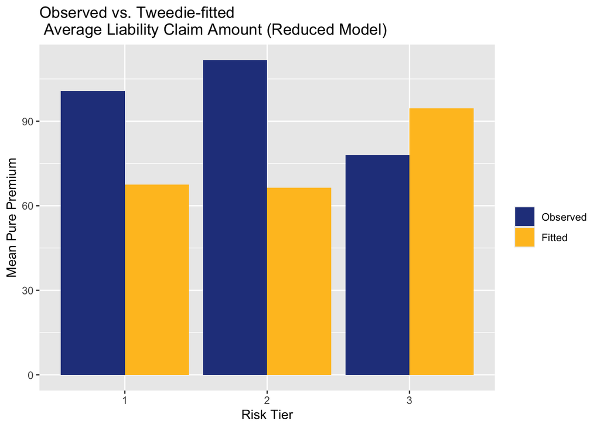

```r
# barplot to compare actual average claim amount vs average predicted claim amount
liability_avg_amt |>
  pivot_longer(cols = c(observed, fitted),
               names_to = "type", values_to = "mean_pp") |>
  mutate(type = factor(type, levels = c("observed", "fitted"),
                       labels = c("Observed", "Fitted"))) |>
  ggplot(aes(x = risk_tier, y = mean_pp, fill = type)) +
  geom_col(position = "dodge") +
  scale_fill_manual(values = c("Observed" = "royalblue4",
                               "Fitted" = "goldenrod1")) +
  labs(title = "Observed vs. Tweedie-fitted \n Average Liability Claim Amount (Reduced Model)",
       x = "Risk Tier", y = "Mean Pure Premium", fill = "")
```

# 4. Guest Medical Protection

## Full Model

```r
training <- data |> filter(training_holdout == "training",
                           coverage == "Guest Medical")
holdout <- data |> filter(training_holdout == "holdout",
                          coverage == "Guest Medical")
```

```r
# estimate Tweedie power index p

profile <- tweedie_profile(
  amount ~ risk_tier + study + gpa + greek + off_campus +
    distance_to_campus + gender + sprinklered,
  data = training, p.vec = seq(1.1, 1.6, by = 0.1),
  link.power = 0, do.plot = FALSE
)
p_hat <- profile$p.max
cat("Estimated Tweedie power p:", round(p_hat, 3))
```

```
## Estimated Tweedie power p: 1.416
```

```r
# fits Tweedie GLM w/ log link
guest_medical_full_model <- glm(
  amount ~ risk_tier + study + gpa + greek + off_campus +
    distance_to_campus + gender + sprinklered,
  data = training,
  family = tweedie(var.power = p_hat, link.power = 0),
  control = glm.control(maxit = 15)
)

summary(guest_medical_full_model)
```

```
##
## Call:
## glm(formula = amount ~ risk_tier + study + gpa + greek + off_campus +
##     distance_to_campus + gender + sprinklered, family = tweedie(var.power = p_hat,
##     link.power = 0), data = training, control = glm.control(maxit = 15))
##
## Coefficients:
##                     Estimate Std. Error t value Pr(>|t|)
## (Intercept)          8.11478    0.66668  12.172  < 2e-16 ***
## risk_tier2           0.35957    0.23849   1.508  0.13167
## risk_tier3           0.28474    0.21505   1.324  0.18551
## studyHumanities     -0.03502    0.25605  -0.137  0.89120
## studyOther          -0.12730    0.26177  -0.486  0.62676
## studyScience        -0.26695    0.26574  -1.005  0.31514
## gpa                 -0.22233    0.10908  -2.038  0.04155 *
## greekNon-greek      -1.43962    0.19516  -7.377 1.79e-13 ***
## off_campusOn campus -1.01776    0.23250  -4.377 1.22e-05 ***
## distance_to_campus   0.05460    0.03105   1.758  0.07874 .
## genderFemale         0.03663    0.55424   0.066  0.94731
## genderMale          -0.08301    0.55535  -0.149  0.88118
## genderOther          0.16746    0.63471   0.264  0.79191
## sprinkleredTRUE     -0.51136    0.19422  -2.633  0.00848 **
## ---
## Signif. codes:  0 '***' 0.001 '**' 0.01 '*' 0.05 '.' 0.1 ' ' 1
##
## (Dispersion parameter for Tweedie family taken to be 2047.541)
##
##     Null deviance: 1765994  on 7998  degrees of freedom
## Residual deviance: 1540789  on 7985  degrees of freedom
## AIC: NA
##
## Number of Fisher Scoring iterations: 10
```

```r
holdout$pred  <- predict(guest_medical_full_model, newdata = holdout, type = "response")

guest_medical_full_avg_amt <- holdout |>
  summarize(observed = mean(amount),
            fitted = mean(pred),
            abs_difference = abs(observed - fitted))
guest_medical_full_avg_amt
```

```
## # A tibble: 1 × 3
##   observed fitted abs_difference
##      <dbl>  <dbl>          <dbl>
## 1     341.   438.           97.7
```

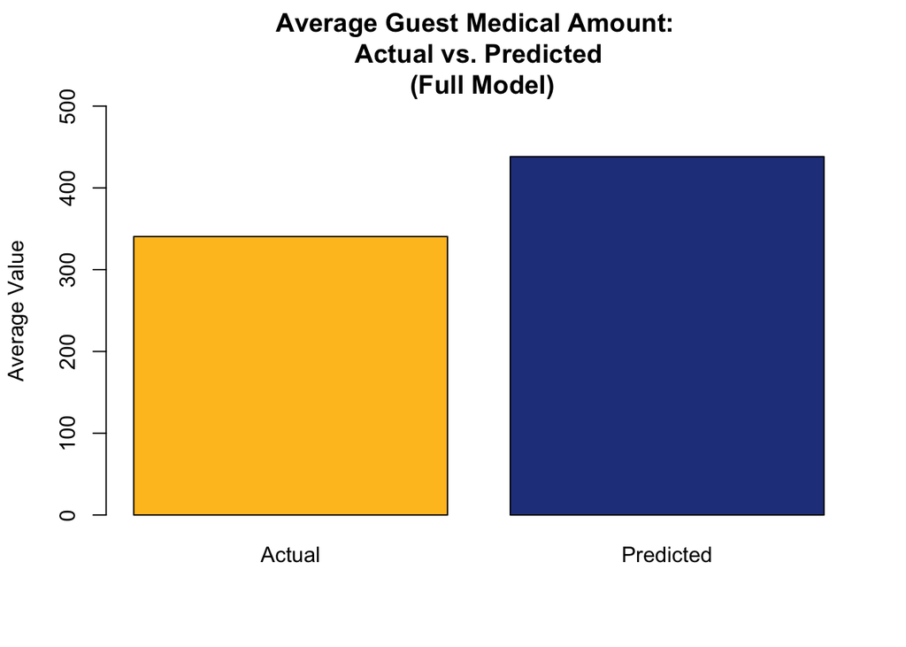

```r
col_means <- colMeans(holdout[c("amount", "pred")])

barplot(col_means,
        col = c("goldenrod1", "royalblue4"),
        main = "Average Guest Medical Amount: \n Actual vs. Predicted \n (Full Model)",
        names.arg = c("Actual", "Predicted"),
        ylim = c(0, 500),
        ylab = "Average Value")
```

```r
guest_medical_full_avg_amt <- holdout |>
  group_by(risk_tier) |>
  summarize(observed = mean(amount),
            fitted = mean(pred),
            abs_difference = abs(observed - fitted))
guest_medical_full_avg_amt
```

```
## # A tibble: 3 × 4
##   risk_tier observed fitted abs_difference
##   <chr>        <dbl>  <dbl>          <dbl>
## 1 1             298.   360.           61.7
## 2 2             347.   533.          186.
## 3 3             398.   492.           93.9
```

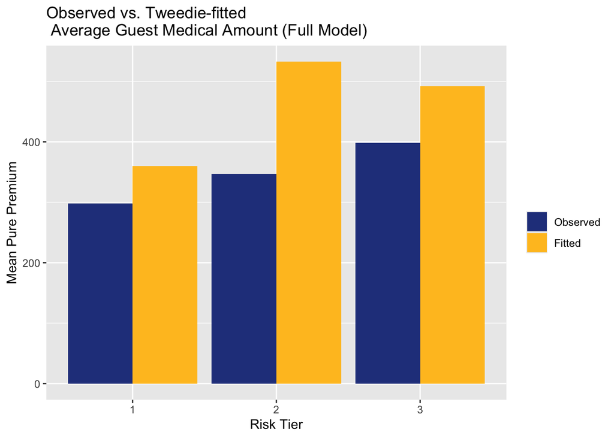

```r
# barplot to compare actual average claim amount vs average predicted claim amount
guest_medical_full_avg_amt |>
  pivot_longer(cols = c(observed, fitted),
               names_to = "type", values_to = "mean_pp") |>
  mutate(type = factor(type, levels = c("observed", "fitted"),
                       labels = c("Observed", "Fitted"))) |>
  ggplot(aes(x = risk_tier, y = mean_pp, fill = type)) +
  geom_col(position = "dodge") +
  scale_fill_manual(values = c("Observed" = "royalblue4",
                               "Fitted" = "goldenrod1")) +
  labs(title = "Observed vs. Tweedie-fitted \n Average Guest Medical Amount (Full Model)",
       x = "Risk Tier", y = "Mean Pure Premium", fill = "")
```

## Variable Selection

### Iteration 1

The table below suggests we drop the variable `gender`.

```r
drop1(guest_medical_full_model, test = "F")
```

```
## Single term deletions
##
## Model:
## amount ~ risk_tier + study + gpa + greek + off_campus + distance_to_campus +
##     gender + sprinklered
##                    Df Deviance  F value    Pr(>F)
## <none>                 1540789
## risk_tier           2  1546608  15.0775 2.912e-07 ***
## study               3  1543190   4.1467  0.006043 **
## gpa                 1  1549681  46.0824 1.215e-11 ***
## greek               1  1647035 550.6095 < 2.2e-16 ***
## off_campus          1  1580268 204.5924 < 2.2e-16 ***
## distance_to_campus  1  1547493  34.7428 3.915e-09 ***
## gender              3  1542077   2.2239  0.083220 .
## sprinklered         1  1554482  70.9623 < 2.2e-16 ***
## ---
## Signif. codes:  0 '***' 0.001 '**' 0.01 '*' 0.05 '.' 0.1 ' ' 1
```

```r
guest_medical_model1 <- update(guest_medical_full_model, ~ . - gender)
summary(guest_medical_model1)
```

```
##
## Call:
## glm(formula = amount ~ risk_tier + study + gpa + greek + off_campus +
##     distance_to_campus + sprinklered, family = tweedie(var.power = p_hat,
##     link.power = 0), data = training, control = glm.control(maxit = 15))
##
## Coefficients:
##                     Estimate Std. Error t value Pr(>|t|)
## (Intercept)          8.09408    0.41052  19.717  < 2e-16 ***
## risk_tier2           0.35421    0.24215   1.463   0.1436
## risk_tier3           0.28836    0.21815   1.322   0.1863
## studyHumanities     -0.04279    0.25986  -0.165   0.8692
## studyOther          -0.12639    0.26524  -0.477   0.6337
## studyScience        -0.27786    0.26984  -1.030   0.3032
## gpa                 -0.22652    0.11060  -2.048   0.0406 *
## greekNon-greek      -1.42370    0.19833  -7.178 7.69e-13 ***
## off_campusOn campus -1.01297    0.23594  -4.293 1.78e-05 ***
## distance_to_campus   0.05476    0.03150   1.738   0.0822 .
## sprinkleredTRUE     -0.48835    0.19740  -2.474   0.0134 *
## ---
## Signif. codes:  0 '***' 0.001 '**' 0.01 '*' 0.05 '.' 0.1 ' ' 1
##
## (Dispersion parameter for Tweedie family taken to be 2110.96)
##
##     Null deviance: 1765994  on 7998  degrees of freedom
## Residual deviance: 1542077  on 7988  degrees of freedom
## AIC: NA
##
## Number of Fisher Scoring iterations: 9
```

### Iteration 2

The table below suggests we stop dropping variables.

```r
drop1(guest_medical_model1, test = "F")
```

```
## Single term deletions
##
## Model:
## amount ~ risk_tier + study + gpa + greek + off_campus + distance_to_campus +
##     sprinklered
##                    Df Deviance  F value    Pr(>F)
## <none>                 1542077
## risk_tier           2  1547866  14.9949 3.162e-07 ***
## study               3  1544628   4.4048  0.004215 **
## gpa                 1  1551396  48.2737 3.998e-12 ***
## greek               1  1647851 547.9154 < 2.2e-16 ***
## off_campus          1  1581171 202.5115 < 2.2e-16 ***
## distance_to_campus  1  1548790  34.7733 3.855e-09 ***
## sprinklered         1  1554827  66.0442 5.071e-16 ***
## ---
## Signif. codes:  0 '***' 0.001 '**' 0.01 '*' 0.05 '.' 0.1 ' ' 1
```

## Final Model

```r
holdout$pred  <- predict(guest_medical_model1, newdata = holdout, type = "response")

guest_medical_avg_amt <- holdout |>
  summarize(observed = mean(amount),
            fitted = mean(pred),
            abs_difference = abs(observed - fitted))
guest_medical_avg_amt
```

```
## # A tibble: 1 × 3
##   observed fitted abs_difference
##      <dbl>  <dbl>          <dbl>
## 1     341.   434.           93.5
```

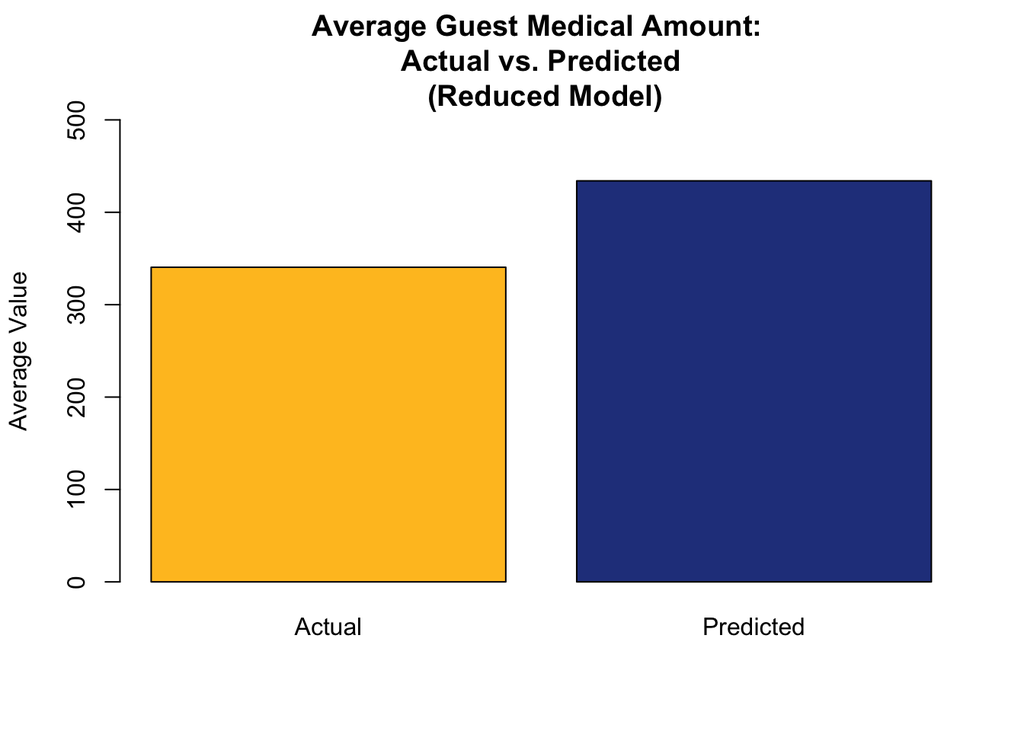

```r
col_means <- colMeans(holdout[c("amount", "pred")])

barplot(col_means,
        col = c("goldenrod1", "royalblue4"),
        main = "Average Guest Medical Amount: \n Actual vs. Predicted \n (Reduced Model)",
        names.arg = c("Actual", "Predicted"),
        ylim = c(0, 500),
        ylab = "Average Value")
```

```r
guest_medical_avg_amt <- holdout |>
  group_by(risk_tier) |>
  summarize(observed = mean(amount),
            fitted = mean(pred),
            abs_difference = abs(observed - fitted))
guest_medical_avg_amt
```

```
## # A tibble: 3 × 4
##   risk_tier observed fitted abs_difference
##   <chr>        <dbl>  <dbl>          <dbl>
## 1 1             298.   356.           58.2
## 2 2             347.   522.          175.
## 3 3             398.   491.           92.8
```

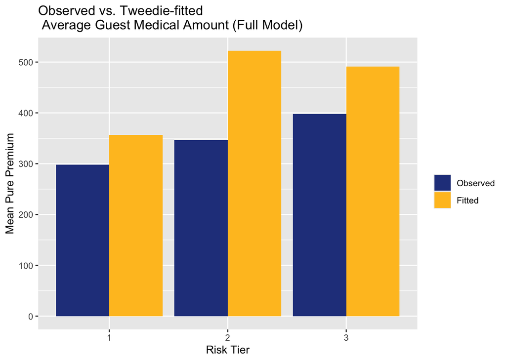

```r
# barplot to compare actual average claim amount vs average predicted claim amount
guest_medical_avg_amt |>
  pivot_longer(cols = c(observed, fitted),
               names_to = "type", values_to = "mean_pp") |>
  mutate(type = factor(type, levels = c("observed", "fitted"),
                       labels = c("Observed", "Fitted"))) |>
  ggplot(aes(x = risk_tier, y = mean_pp, fill = type)) +
  geom_col(position = "dodge") +
  scale_fill_manual(values = c("Observed" = "royalblue4",
                               "Fitted" = "goldenrod1")) +
  labs(title = "Observed vs. Tweedie-fitted \n Average Guest Medical Amount (Full Model)",
       x = "Risk Tier", y = "Mean Pure Premium", fill = "")
```